# Costly conversion data challenge

## Sales over time

I want to start exploring sales over time. There are a lot of ways to break down sales over time: by region, by genre, and by region and genre.

I’m going to iterate through those different views in order to get a fuller understanding of sales.

An initial hurdle to some visualization approaches is that there are many year, region, and genre combinations where there are no sales recoded. I’m going to fill those empty values with 0s to improve plotting. These NAs are probably created by no sales of that genre in any region that year; sales only in regions outside of Europe, Japan, or North America; or no games of that genre for sale that year.

```r
#' Fill in empty sales data for unobserved combinations
#'
#' @param data tibble or dataframe with 4 columns: year, region, genre, and sales
#' @return a tibble
fill_empty <- function(data) {
  years <- expand.grid(year = unique(data$year),
                       region = unique(data$region),
                       genre = unique(data$genre)) %>%
  as_tibble() %>%
  mutate(year = as.numeric(year),
         region = as.character(region),
         genre = as.character(genre))

  out <-
    years %>%
    left_join(data,
              by = c('year','region', 'genre')) %>%
    mutate(sales = if_else(is.na(sales), 0, sales))

  out
}

# sales data over time
sales_time <-
  vg_sales %>%
  drop_na() %>%
  dplyr::select(year, genre, na_sales, eu_sales, jp_sales) %>%
  pivot_longer(-c(year, genre),
               names_to = 'region',
               values_to = 'sales') %>%
  fill_empty(data = .)
```

Now that there is a sales value for every year-region-genre combo, I’m going to make some graphs.

First, let’s observe regional sales over time, both cumulative and per year.

Because I’m going to be doing a similar operation but using genre next, I’m going to write the summary procedure as a function. I use tidy evaluation to improve the portability of the function.

I also have a small function for generating line labels that can be placed at the end of a time series. I’m conflicted on whether to use them in this presentation, but I’d rather have the option than not. Especially given that I’ve written it right now, I could use it in future iterations.

```r
#' Repeat operation to group sales data and calculate useful information.
#'
#' Uses tidy evaluation
#'
#' @param data tibble or data.frame
#' @group_var grouping variable
#' @time_var time variable
#' @value_var value to operate on
#' @names_to character name for summary names
#' @group_var character name of summary values
#' @return a tibble object
prep_oneway <- function(data, group_var, time_var, value_var, names_to, values_to) {
  group_var = enquo(group_var)
  time_var = enquo(time_var)
  value_var = enquo(value_var)

  data %>%
    group_by(!!group_var, !!time_var) %>%
    arrange(year) %>%
    summarize(value = sum(!!value_var)) %>%
    mutate(value_cum = cumsum(value)) %>%
    pivot_longer(-c(!!group_var, !!time_var),
                 names_to = names_to,
                 values_to = values_to)
}

#' Generate quick and dirty labels for time series ends
#'
#' @param max_var numeric vector where max_var is most recent time value (ascending)
#' @param label_var character vector what string to display at end of series
#' @return boolean vector
label_series <- function(max_var, label_var) {
  if_else(max_var == max(max_var, na.rm = TRUE),
          label_var,
          NA_character_)
}
```

Given these functions, let’s create a plot of sales over time. This is mostly label cleaning and plotting details.

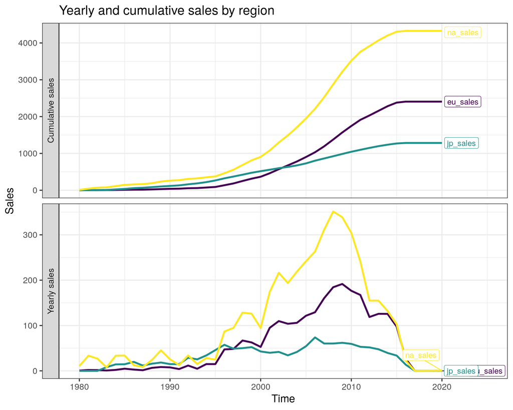

```r
sales_time_region <-
  sales_time %>%
  prep_oneway(group_var = region,
              time_var = year,
              value_var = sales,
              names_to = 'sales_type',
              values_to = 'value') %>%
  mutate(region_full = case_when(region == 'eu_sales' ~ 'Europe',
                                 region == 'jp_sales' ~ 'Japan',
                                 region == 'na_sales' ~ 'North America'),
         sales_type_full =
           case_when(sales_type == 'value' ~ 'Yearly sales',
                     sales_type == 'value_cum' ~ 'Cumulative sales'))


sales_time_region %>%
  mutate(label = label_series(max_var = year, label_var = region)) %>%
  ggplot(aes(x = year, y = value, color = region_full)) +
  geom_line(size = 1.25) +
  facet_grid(sales_type_full ~ .,
             scales = 'free_y',
             switch = 'y') +
  geom_label_repel(aes(label = label),
                   nudge_x = 0.5,
                   na.rm = TRUE,
                   segment.size = 0.5) +
  expand_limits(x = 2025) +
  scale_color_viridis(discrete = TRUE) +
  theme(legend.position = 'none') +
  labs(x = 'Time',
       y = 'Sales',
       title = 'Yearly and cumulative sales by region')
```

Genre over time

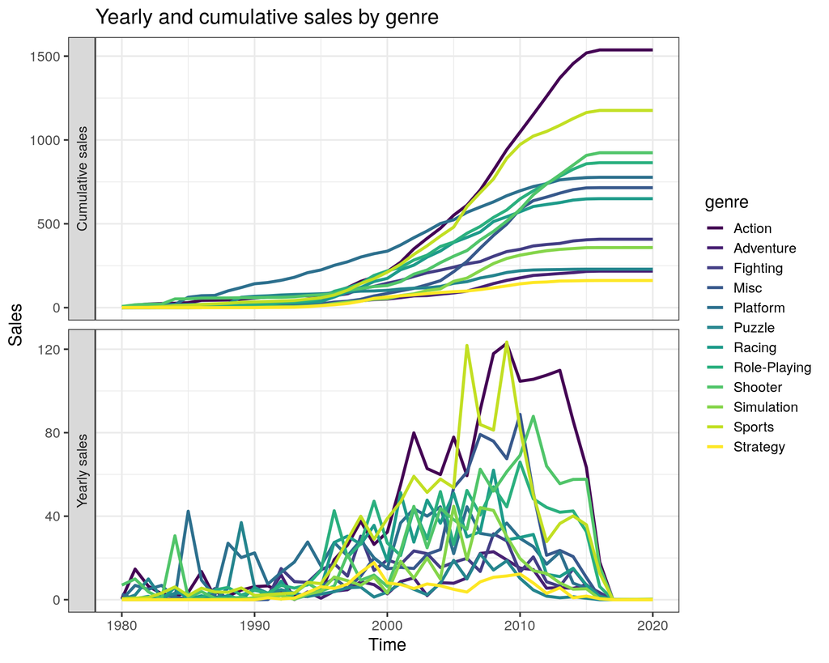

```r
sales_time_genre <-
  sales_time %>%
  prep_oneway(group_var = genre,
              time_var = year,
              value_var = sales,
              names_to = 'sales_type',
              values_to = 'value') %>%
  mutate(sales_type_full =
         case_when(sales_type == 'value' ~ 'Yearly sales',
                   sales_type == 'value_cum' ~ 'Cumulative sales'))

sales_time_genre %>%
  #mutate(label = label_series(max_var = year, label_var = genre)) %>%
  ggplot(aes(x = year, y = value, colour = genre)) +
  geom_line(size = 1.25) +
  facet_grid(sales_type_full ~ .,
             scales = 'free_y',
             switch = 'y') +
  #geom_label_repel(aes(label = label),
  #                 nudge_x = 0.5,
  #                 na.rm = TRUE,
  #                 segment.size = 0.5) +
  #expand_limits(x = 2025) +
  scale_color_viridis(discrete = TRUE) +
  #theme(legend.position = 'none') +
  labs(x = 'Time',
       y = 'Sales',
       title = 'Yearly and cumulative sales by genre')
```

Region and genre over time.

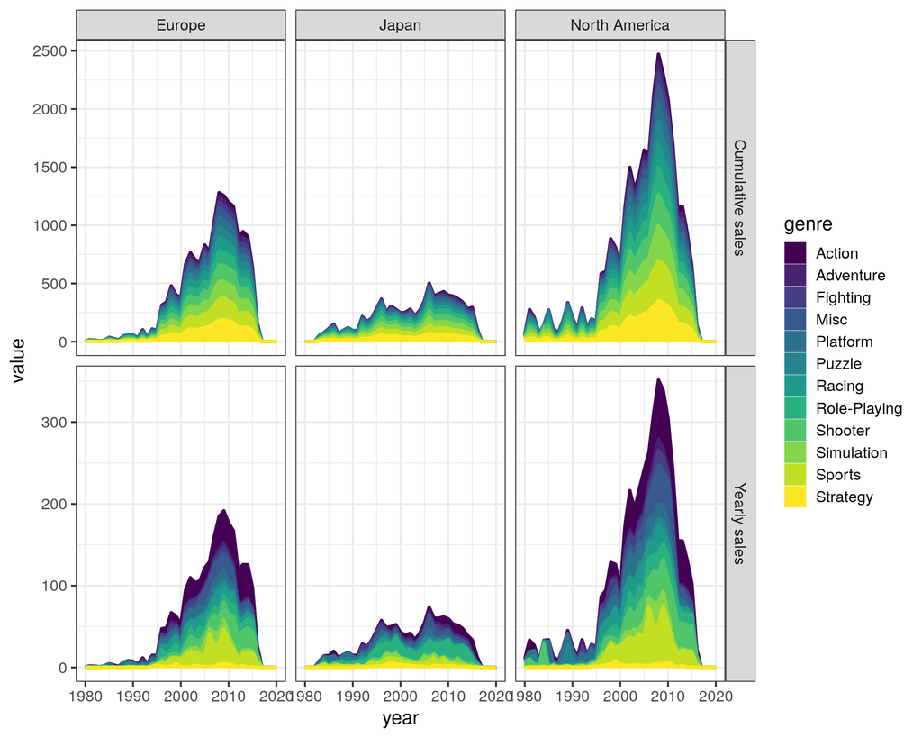

```r
sales_time_region_genre <-
  sales_time %>%
  group_by(region, year, genre) %>%
  arrange(year) %>%
  summarize(sales = sum(sales)) %>%
  mutate(sales_cum = cumsum(sales)) %>%
  pivot_longer(-c(region, year, genre),
               names_to = 'sales_type',
               values_to = 'value') %>%
  mutate(region_full = case_when(region == 'eu_sales' ~ 'Europe',
                                 region == 'jp_sales' ~ 'Japan',
                                 region == 'na_sales' ~ 'North America'),
         sales_type_full =
           case_when(sales_type == 'sales' ~ 'Yearly sales',
                     sales_type == 'sales_cum' ~ 'Cumulative sales'))

sales_time_region_genre %>%
  #mutate(label = if_else(year == max(year, na.rm = TRUE),
  #                       region_full,
  #                       NA_character_)) %>%
  ggplot(aes(x = year, y = value,
             color = genre, fill = genre)) +
  geom_area() +
  geom_line(size = 1.25, position = 'stack') +
  facet_grid(sales_type_full ~ region_full,
             scales = 'free_y') +
  scale_fill_viridis(discrete = TRUE) +
  scale_colour_viridis(discrete = TRUE)
```